# Course Project: Shiny App Presentation(press next arrow)

15/01/2021

## Description of the course project

In this project, we were asked to write a shiny application with the following description:

- It should contain a documentation explaining what the user needs to get started with the shiny application,
- It should be deployed on the Rstudio’s shiny server,
- The server.R and ui.R code should be shared on github.

**Press the next arrow to move to the next slide.**

## The idea picth in the shiny app

The shny App presented here was created using the insurance dataset from https://www.kaggle.com/mirichoi0218/insurance.

It has 1338 observations for 7 variables among which: age, sex, bmi, children, smoker, region and charges.In this app, we show how the medical charges vary by bmi using a linear regression model fitted in the selected data.

Also, a summary of the fitted model is displayed to see it performance each time the data is selected. Furthermore, calculation of the predicted charges for a selected bmi is also displayed.

## How to use this shiny app

Everything needed to get started with the application is all embedded in the documentation panel of our app. You would find the application running using https://census2020.shinyapps.io/Shiny-Application/.

Also, the server.R and ui.R code could be found using https://github.com/AnalystJanine1/Shiny-App.

## Example of plot and and predicted charges

```
## The predicted charge for a bmi of  25 is: 23856.44 dollars.
```

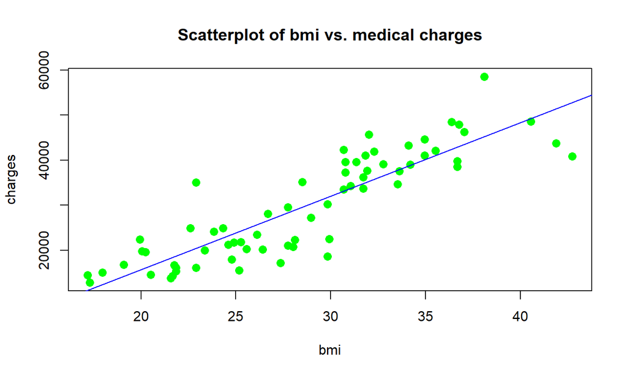